# Praca Domowa 1

Bartłomiej Eljasiak

24 03 2020

# coxed

## Loading libraries

I had slight problems whith installing **codex**, becouse it’s not done with ususal *install.packages()*, and author said nothing about it, but it is not that important.

```r
## Packages ##
library(coxed)
library(ggplot2)
library(dplyr)


## Load and prepare data ##
data(martinvanberg)
set.seed(2443)
```

## Model estimation

Works fine

```r
mv.surv <- Surv(martinvanberg$formdur, event = rep(1, nrow(martinvanberg)))
mv.cox <- coxph(mv.surv ~ postel + prevdef + cont + ident + rgovm + pgovno +
                  tpgovno + minority, data = martinvanberg)
```

## Codex usage

Despite warnings works fine

```r
ed <- coxed(mv.cox, method = "gam", bootstrap = TRUE, B = 30)
```

```
## Warning in coxph.fit(x, y, strata = strata, method = "efron", rownames =
## rownames(x), : Loglik converged before variable 1,2,4,5,6 ; coefficient may be
## infinite.
```

## Head()

Slight differences in values

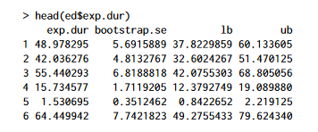

```r
head(ed$exp.dur)
```

```
##     exp.dur bootstrap.se         lb        ub
## 1 47.601963     5.215412 37.3799426 57.823983
## 2 41.742687     4.699803 32.5312421 50.954132
## 3 55.030383     6.834828 41.6343653 68.426401
## 4 15.906172     2.198640 11.5969169 20.215428
## 5  1.538833     0.435554  0.6851633  2.392504
## 6 65.632840     9.037242 47.9201718 83.345508
```

## Summary() function

Slight differences in values

### Original

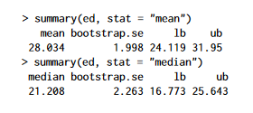

### Reproduced

```r
summary(ed, stat = "mean")
```

```
##    mean bootstrap.se     lb     ub
##  28.034         1.99 24.134 31.935
```

```r
summary(ed, stat = "median")
```

```
##  median bootstrap.se     lb     ub
##  20.996        2.617 15.866 26.126
```

## Codex function usage on data.frame

Rather big differences in values

### Original

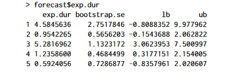

```r
new.coalitions <- data.frame(postel = c(1, 1, 1, 0, 1),
                             prevdef = c(0, 0, 1, 1, 0),
                             cont = c(1, 0, 1, 0, 1),
                             ident = c(1, 2, 2, 3, 3),
                             rgovm = c(.3, .8, 1.1, .2, .35),
                             pgovno = c(2, 3, 3, 2, 4),
                             tpgovno = c(3.2, 0, 5, 0, 2.6),
                             minority = c(0, 0, 1, 0, 0))
forecast <- coxed(mv.cox, newdata = new.coalitions, method = "gam",
                  bootstrap = TRUE, B = 30)
forecast$exp.dur
```

```
##     exp.dur bootstrap.se         lb       ub
## 1 2.9915496    3.0838374 -3.0526606 9.035760
## 2 0.9997589    1.9358168 -2.7943724 4.793890
## 3 4.6530881    1.5457774  1.6234200 7.682756
## 4 1.3529036    2.3512771 -3.2555148 5.961322
## 5 1.4449630    0.9410979 -0.3995549 3.289481
```

## Figure 1

Works fine, looks a bit different but represents the same

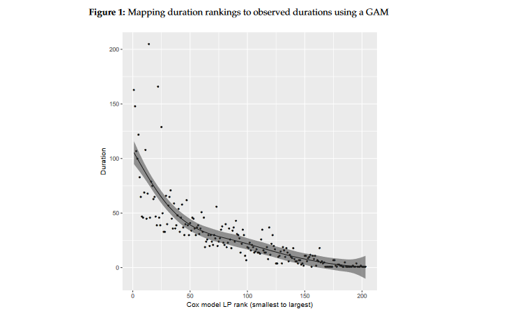

### Reproduced

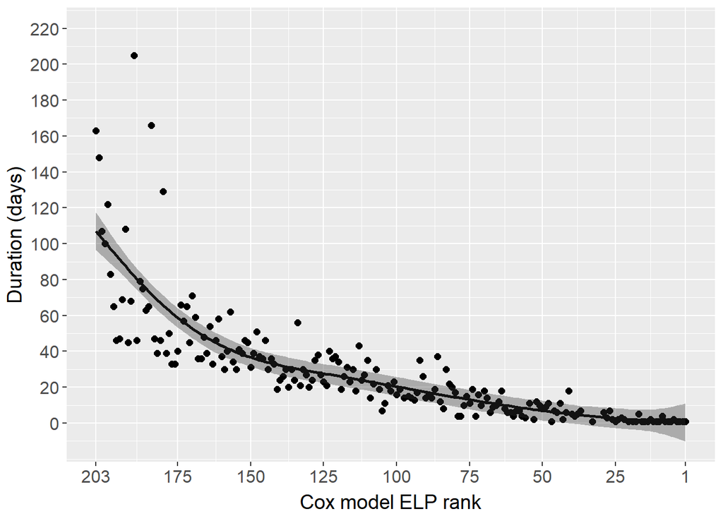

```r
## Plot ELP rank against expected duration ##
d.mvlped <- data.frame(rank = 1:nrow(ed$gam.data), x = ed$gam.data$rank.xb, y = ed$gam.data$y, pe = ed$gam.data$gam_fit, lo = ed$gam.data$gam_fit_95lb, hi = ed$gam.data$gam_fit_95ub, failed = ed$gam.data$failed)

ggplot(d.mvlped, aes(x = x, y = y)) +
  geom_point(shape = 16, position = "identity", color = "black", lwd = 2) +
  geom_line(aes(x = x, y = pe), color = "black", lwd = 1) +
  geom_ribbon(aes(x = x, min = lo, max = hi), alpha = .35) +
  scale_y_continuous(limits = c(-10.2, 220), breaks = seq(0, 220, 20)) +
  scale_x_continuous(breaks = c(max(ed$gam.data$rank.xb), seq(29, 179, 25), min(ed$gam.data$rank.xb)), labels = (nrow(ed$gam.data) + 1) - c(max(ed$gam.data$rank.xb), seq(29, 179, 25), min(ed$gam.data$rank.xb)), minor_breaks = c(15, 42, 67, 92, 117, 141, 166, 191)) +
  theme(legend.position = "none", axis.text = element_text(size = 12), axis.title.y = element_text(size = 14, vjust = 1.5), axis.title.x = element_text(size = 14, vjust = -.1)) + labs(fill = "") +
  ylab("Duration (days)") + xlab("Cox model ELP rank")
```

## Codex again

According to warning there are some problems with the code. I tried to take a closer look, but sadly I was unable to find definite answer dose it impact the results.

```r
me <- coxed(mv.cox, method = "gam", bootstrap = TRUE, B = 30,
            newdata = mutate(martinvanberg, rgovm = 0),
            newdata2 = mutate(martinvanberg, rgovm = 1.24))
```

```
## Warning in rank.predict(x = exp.xb2, v = exp.xb, warn = warn): New data
## contain 2 observations with linear predictors less than or equal to all linear
## predictors in the estimation sample. These observations will all have the same
## predicted duration
```

```
## Warning in rank.predict(x = exp.xb2, v = exp.xb, warn = warn): New data
## contain 1 observations with linear predictors less than or equal to all linear
## predictors in the estimation sample. These observations will all have the same
## predicted duration
```

## Summary again

Slight differences in values

### Original

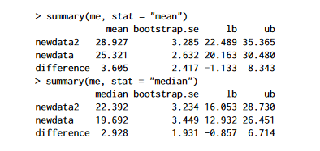

### Reproduced

```r
summary(me, stat = "mean")
```

```
##              mean bootstrap.se     lb     ub
## newdata2   29.299        2.156 25.073 33.525
## newdata    25.569        2.396 20.873 30.264
## difference  3.730        1.808  0.187  7.273
```

```r
summary(me, stat = "median")
```

```
##            median bootstrap.se     lb     ub
## newdata2   22.536        2.459 17.716 27.356
## newdata    19.609        3.066 13.601 25.618
## difference  3.469        1.306  0.909  6.030
```

## Diffrences summary

- **Diffrent values**

- **Diffrences in plot**

It seems that the author did update the plot but did not update the code for it, so what I was able to reproduce is uglier version of the same picture.

## Conclusion

The package works fine, but the author could pay a closer atention to code that he attached. I would say that becouse of slight differences between what article shows and what code outputs the article is irreproducible. Nevertheless article does not misguide users when it comes to using the package, so this irreproduciblity in my opinion is not very serious. Article or code ought to be corrected but there is no reason to put it down or take other extreme measures.

# lpirfs

I was very happy to analize this article because autor attached all code from it. Very easly we can follow his resoults just by launching `adaemmer.R`, this is great example of an article that takes into account more that sheer content in .pdf file. Let’s follow the author then, funnily enough it starts with reproduction of results of a different author.

## Replicating results by Jordà (2005)

### Table - Original

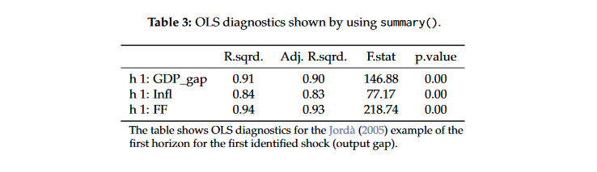

### Table - Reproduced

```r
library(lpirfs)
library(ggpubr)
library(gridExtra)

endog_data  <- interest_rules_var_data
results_lin <- lp_lin(endog_data     = endog_data,lags_endog_lin = 4,trend          = 0,shock_type     = 1,confint        = 1.96,hor            = 12)

summary(results_lin)[[1]][1]
```

```
## [[1]]
##              R-sqrd. Adj. R-sqrd.   F-stat      p-value
## h1:GDP_gap 0.9092137    0.9030238 146.8850 6.566021e-85
## h1:Infl    0.8403042    0.8294158  77.1746 1.707770e-63
## h1:FF      0.9371636    0.9328793 218.7439 6.592407e-99
```

### Figure 1 - Original

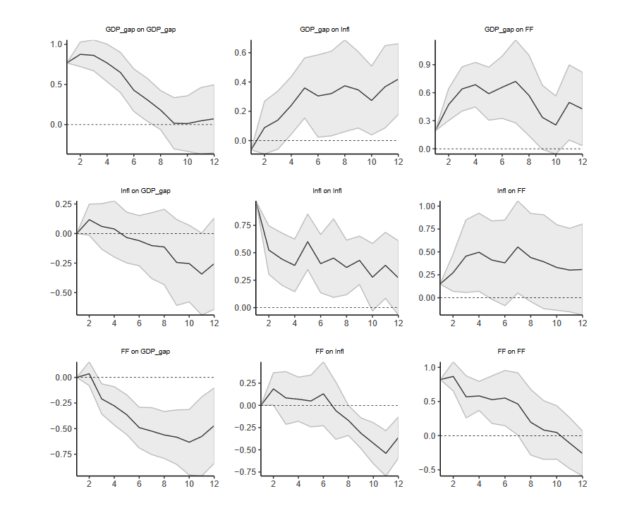

### Figure 1 - Reproduced

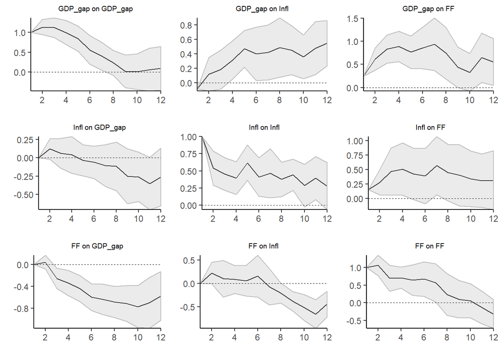

```r
plot(results_lin)
```

### Figure 2 - Original

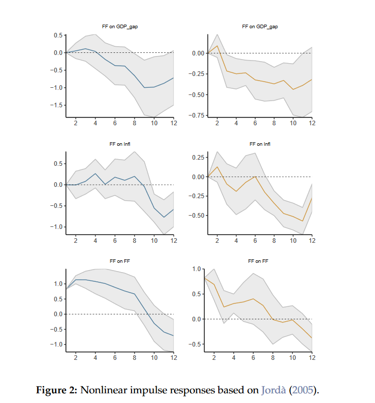

### Figure 2 - Reproduced

**Copy from attached file**

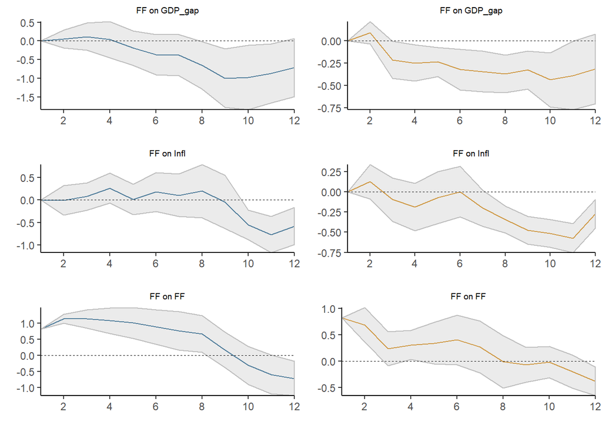

```r
################################################################################
#                 ---  Code for Figure 2 ---
################################################################################

 # Choose data for switching variable (here Federal Funds Rate)
 switching_data <-  if_else(dplyr::lag(endog_data$Infl, 3) > 4.75, 1, 0)


 # switching_data_log <-  dplyr::lag(endog_data$Infl, 3) %>%
 #                      replace_na(0)

 # Estimate model and save results
 results_nl    <- lp_nl(endog_data,
                        lags_endog_lin  = 4,
                        lags_endog_nl   = 4,
                        trend           = 0,
                        shock_type      = 0,
                        confint         = 1.96,
                        hor             = 12,
                        switching       = switching_data,
                        lag_switching   = F,
                        use_logistic    = F)


 # Use plot functions
 nl_plots <- plot_nl(results_nl)

 # Combine plots by using 'ggpubr' and 'gridExtra'
 single_plots      <- nl_plots$gg_s1[c(3, 6, 9)]
 single_plots[4:6] <- nl_plots$gg_s2[c(3, 6, 9)]

 all_plots <- sapply(single_plots, ggplotGrob)

 # Show all plots
 nl_all_plots <- marrangeGrob(all_plots, nrow = 3, ncol = 2, top = NULL)
 nl_all_plots
```

```r
# --- End code for Figure 2
```

## Figure 3

### Original

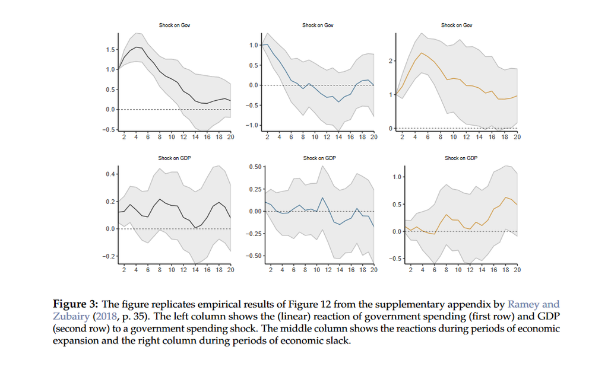

### Reproduced

**Copy from attached file**

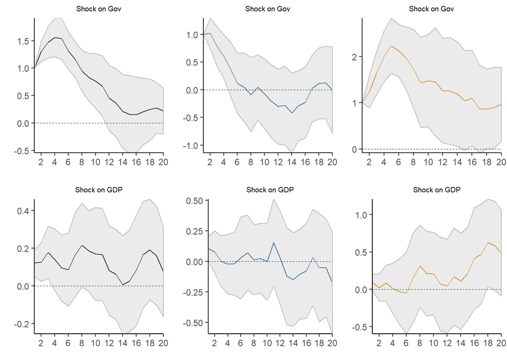

```r
################################################################################
#                 ---  Code for Figure 3 ---
################################################################################


# Load data
 ag_data       <- ag_data
 sample_start  <- 7
 sample_end    <- dim(ag_data)[1]

# Endogenous data
 endog_data    <- ag_data[sample_start:sample_end,3:5]

# Variable to shock with. Here government spending due to
# Blanchard and Perotti (2002) framework
 shock         <- ag_data[sample_start:sample_end, 3]

# Estimate linear model
 results_lin_iv <- lp_lin_iv(endog_data,
                             lags_endog_lin = 4,
                             shock          = shock,
                             trend          = 0,
                             confint        = 1.96,
                             hor            = 20)


# Make and save plots
 iv_lin_plots    <- plot_lin(results_lin_iv)

# This example replicates results from the Supplementary Appendix
# by Ramey and Zubairy (2018) (RZ-18).

# Load and prepare data
 ag_data           <- ag_data
 endog_data        <- ag_data[sample_start:sample_end, 3:5]

# The nonlinear shock is estimated by RZ-18.
 shock             <- ag_data[sample_start:sample_end, 7]

# Include four lags of the 7-quarter moving average growth rate of GDP
# as exogenous variables (see RZ-18)
 exog_data         <- ag_data[sample_start:sample_end, 6]

# Use the 7-quarter moving average growth rate of GDP as switching variable
# and adjust it to have suffiently long recession periods.
 switching_variable <- ag_data$GDP_MA[sample_start:sample_end] - 0.8

# Estimate local projections
 results_nl_iv <- lp_nl_iv(endog_data,
                           lags_endog_nl     = 3,
                           shock             = shock,
                           exog_data         = exog_data,
                           lags_exog         = 4,
                           trend             = 0,
                           confint           = 1.96,
                           hor               = 20,
                           switching         = switching_variable,
                           use_hp            = FALSE,
                           gamma             = 3)

# Make and save plots
 plots_nl_iv <- plot_nl(results_nl_iv)

# Make to list to save all plots
 combine_plots <- list()

# Save linear plots in list
 combine_plots[[1]] <- iv_lin_plots[[1]]
 combine_plots[[2]] <- iv_lin_plots[[3]]

# Save nonlinear plots for expansion period
 combine_plots[[3]] <- plots_nl_iv$gg_s1[[1]]
 combine_plots[[4]] <- plots_nl_iv$gg_s1[[3]]

# Save nonlinear plots for recession period
 combine_plots[[5]] <- plots_nl_iv$gg_s2[[1]]
 combine_plots[[6]] <- plots_nl_iv$gg_s2[[3]]

 lin_plots_all     <- sapply(combine_plots, ggplotGrob)
 combine_plots_all <- marrangeGrob(lin_plots_all, nrow = 2, ncol = 3, top = NULL)
 combine_plots_all
```

```r
 # --- End code for Figure 3
```

## Figure 4

### Original

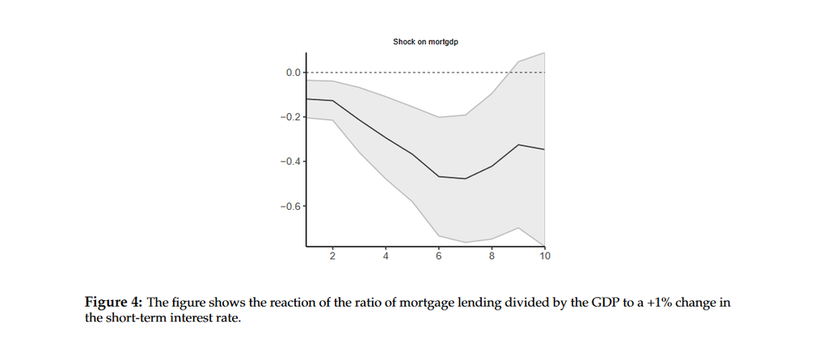

### Reproduced

**Copy from attached file**

```r
################################################################################
#                 ---  Code for Figure 4 ---
################################################################################

# Load necessary libraries
  library(httr)
  library(readxl)
  library(dplyr)

# Retrieve the external JST Macrohistory Database
  url_jst <-"http://www.macrohistory.net/JST/JSTdatasetR3.xlsx"
  GET(url_jst, write_disk(jst_link <- tempfile(fileext = ".xlsx")))
```

```
## Response [http://www.macrohistory.net/JST/JSTdatasetR3.xlsx]
##   Date: 2020-04-07 23:12
##   Status: 200
##   Content-Type: application/vnd.openxmlformats-officedocument.spreadsheetml.sheet
##   Size: 635 kB
## <ON DISK>  C:\Users\Bartek\AppData\Local\Temp\RtmpKkO6sy\file5a001a2b6e74.xlsx
```

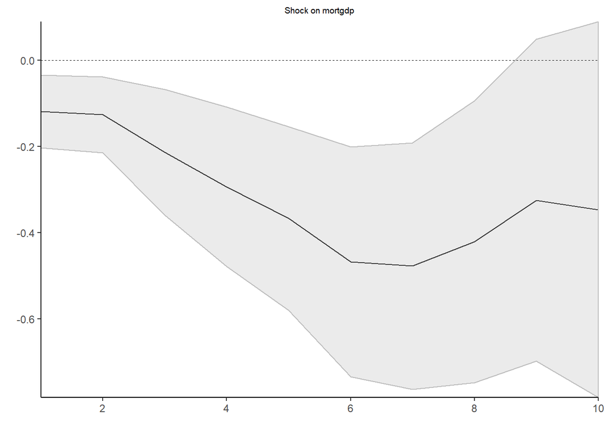

```r
  jst_data <- read_excel(jst_link, 2L)

# Swap the first two columns
  jst_data <- jst_data                    %>%
              dplyr::filter(year <= 2013) %>%
              dplyr::select(country, year, everything())

# Prepare variables
  data_set <- jst_data %>%
             mutate(stir    = stir)                         %>%
             mutate(mortgdp = 100*(tmort/gdp))              %>%
             mutate(hpreal  = hpnom/cpi)                    %>%
             group_by(country)                              %>%
             mutate(hpreal  = hpreal/hpreal[year==1990][1]) %>%
             mutate(lhpreal = log(hpreal))                  %>%

             mutate(lhpy    = lhpreal - log(rgdppc))        %>%
             mutate(lhpy    = lhpy - lhpy[year == 1990][1]) %>%
             mutate(lhpreal = 100*lhpreal)                  %>%
             mutate(lhpy    = 100*lhpy)                     %>%
             ungroup()                                      %>%

             mutate(lrgdp   = 100*log(rgdppc))              %>%
             mutate(lcpi    = 100*log(cpi))                 %>%
             mutate(lriy    = 100*log(iy*rgdppc))           %>%
             mutate(cay     = 100*(ca/gdp))                 %>%
             mutate(tnmort  = tloans - tmort)               %>%
             mutate(nmortgdp = 100*(tnmort/gdp))            %>%
             dplyr::select(country, year, mortgdp, stir, ltrate,
                                                    lhpy, lrgdp, lcpi, lriy, cay, nmortgdp)


# Exclude observations from WWI and WWII
  data_sample <- seq(1870, 2016)[which(!(seq(1870, 2016) %in%
                                            c(seq(1914, 1918),
                                            seq(1939, 1947))))]

# Estimate linear panel model
  results_panel <- lp_lin_panel(data_set  = data_set,  data_sample  = data_sample,
                                endog_data        = "mortgdp", cumul_mult   = TRUE,
                                shock             = "stir",    diff_shock   = TRUE,
                                panel_model       = "within",  panel_effect = "individual",
                                robust_cov        = "vcovSCC", c_exog_data  = "cay",
                                c_fd_exog_data    = colnames(data_set)[c(seq(4,9),11)],
                                l_fd_exog_data    = colnames(data_set)[c(seq(3,9),11)],
                                lags_fd_exog_data = 2,      confint      = 1.67,
                                hor               = 10)

# Create and plot irfs
  plot_lin_panel <- plot_lin(results_panel)
  plot(plot_lin_panel[[1]])
```

```r
# --- End code for Figure 4
```

## Figure 5

### Original

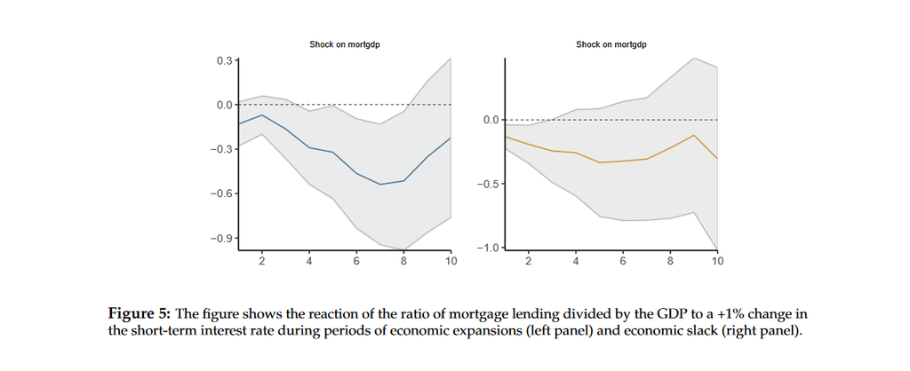

### Reproduced

**Copy from attached file**

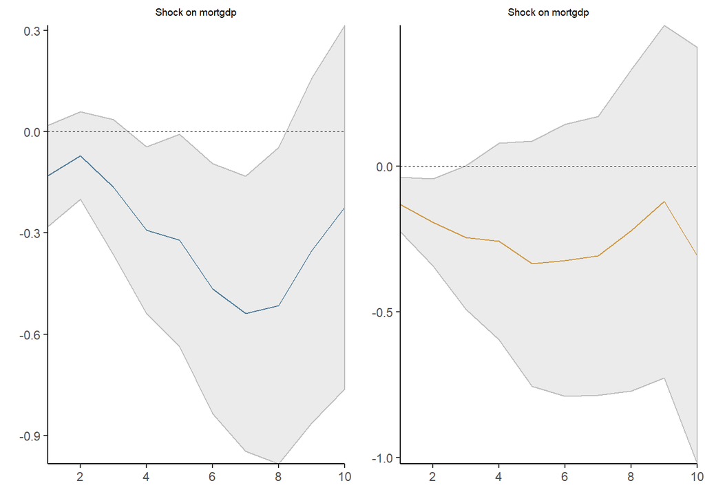

```r
################################################################################
#                 ---  Code for Figure 5 ---
################################################################################


# Estimate panel model
 results_panel <- lp_nl_panel(data_set          = data_set,
                              data_sample       = data_sample,
                              endog_data        = "mortgdp", cumul_mult     = TRUE,
                              shock             = "stir",    diff_shock     = TRUE,
                              panel_model       = "within",  panel_effect   = "individual",
                              robust_cov        = "vcovSCC", switching      = "lrgdp",
                              lag_switching     = TRUE,      use_hp         = TRUE,
                              lambda            = 6.25,      gamma          = 10,
                              c_exog_data       = "cay",
                              c_fd_exog_data    = colnames(data_set)[c(seq(4,9),11)],
                              l_fd_exog_data    = colnames(data_set)[c(seq(3,9),11)],
                              lags_fd_exog_data = 2,
                              confint           = 1.67,
                              hor               = 10)

# Create and show linear plots
  nl_plots      <- plot_nl(results_panel)
  combine_plots <- list(nl_plots$gg_s1[[1]], nl_plots$gg_s2[[1]])
  nonlinear_panel_plots <- marrangeGrob(combine_plots, nrow = 1, ncol = 2, top = NULL)
  nonlinear_panel_plots
```

```r
# --- End code for Figure 5
```

**Important comment** There are 3 more figures shown in the article after the summary, they cannot be found in provided code, but as author states. All code can be found in the [vigette](https://cran.r-project.org/web/packages/lpirfs/vignettes/lpirfs_vignette.html) of the package.

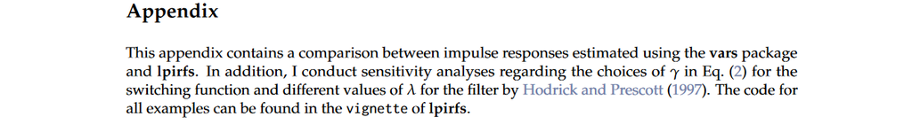

# MANOVA.RM

## Example 1

### Original

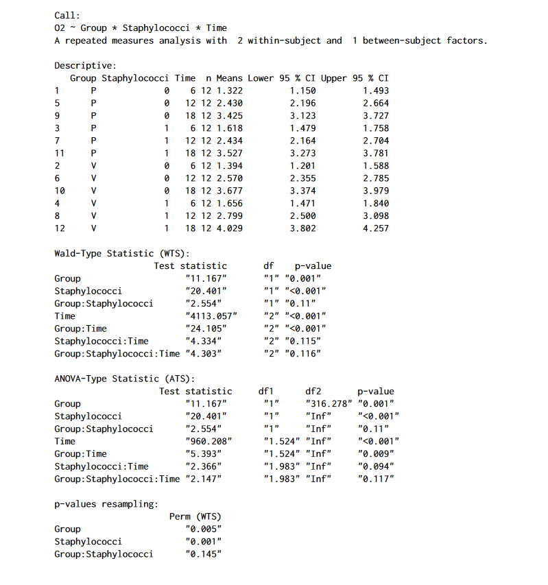

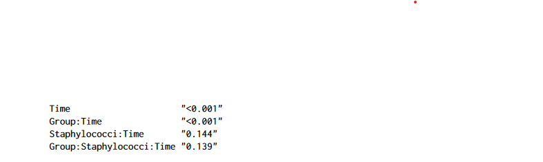

### Reproduced

**Copy from attached file**

```r
detach("package:ggplot2", force = TRUE)
detach("package:ggpubr", force = TRUE)
detach("package:gridExtra", force = TRUE)
library(MANOVA.RM)

# Example 1
data("o2cons")
model1 <- RM(O2 ~ Group * Staphylococci * Time, data = o2cons,
           subject = "Subject",  no.subf = 2, iter = 1000,
               resampling = "Perm", seed = 1234)
summary(model1)
```

```
## Call:
## O2 ~ Group * Staphylococci * Time
## A repeated measures analysis with  2 within-subject and  1 between-subject factors.
##
## Descriptive:
##    Group Staphylococci Time  n Means Lower 95 % CI Upper 95 % CI
## 1      P             0    6 12 1.322         1.150         1.493
## 5      P             0   12 12 2.430         2.196         2.664
## 9      P             0   18 12 3.425         3.123         3.727
## 3      P             1    6 12 1.618         1.479         1.758
## 7      P             1   12 12 2.434         2.164         2.704
## 11     P             1   18 12 3.527         3.273         3.781
## 2      V             0    6 12 1.394         1.201         1.588
## 6      V             0   12 12 2.570         2.355         2.785
## 10     V             0   18 12 3.677         3.374         3.979
## 4      V             1    6 12 1.656         1.471         1.840
## 8      V             1   12 12 2.799         2.500         3.098
## 12     V             1   18 12 4.029         3.802         4.257
##
## Wald-Type Statistic (WTS):
##                          Test statistic df  p-value
## Group                    "11.167"       "1" "0.001"
## Staphylococci            "20.401"       "1" "<0.001"
## Group:Staphylococci      "2.554"        "1" "0.11"
## Time                     "4113.057"     "2" "<0.001"
## Group:Time               "24.105"       "2" "<0.001"
## Staphylococci:Time       "4.334"        "2" "0.115"
## Group:Staphylococci:Time "4.303"        "2" "0.116"
##
## ANOVA-Type Statistic (ATS):
##                          Test statistic df1     df2      p-value
## Group                    "11.167"       "1"     "57.959" "0.001"
## Staphylococci            "20.401"       "1"     "Inf"    "<0.001"
## Group:Staphylococci      "2.554"        "1"     "Inf"    "0.11"
## Time                     "960.208"      "1.524" "Inf"    "<0.001"
## Group:Time               "5.393"        "1.524" "Inf"    "0.009"
## Staphylococci:Time       "2.366"        "1.983" "Inf"    "0.094"
## Group:Staphylococci:Time "2.147"        "1.983" "Inf"    "0.117"
##
## p-values resampling:
##                          Perm (WTS)
## Group                    "0.003"
## Staphylococci            "<0.001"
## Group:Staphylococci      "0.128"
## Time                     "<0.001"
## Group:Time               "<0.001"
## Staphylococci:Time       "0.134"
## Group:Staphylococci:Time "0.148"
```

## Example 2

### Original

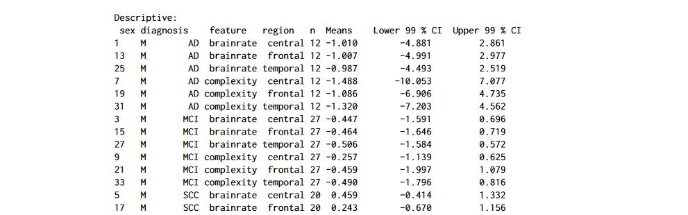

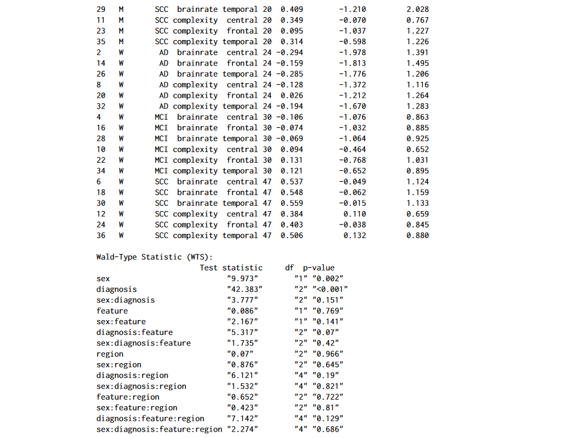

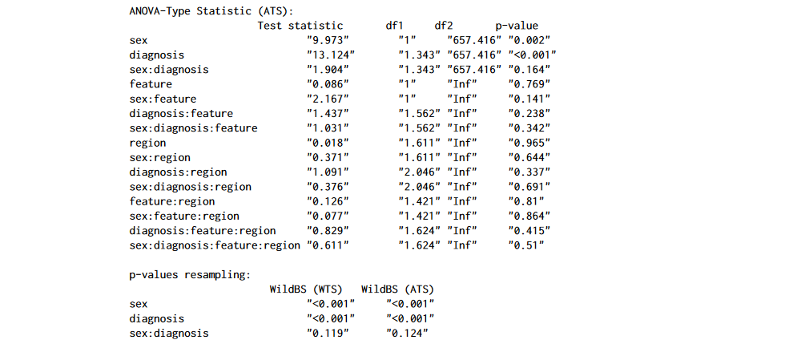

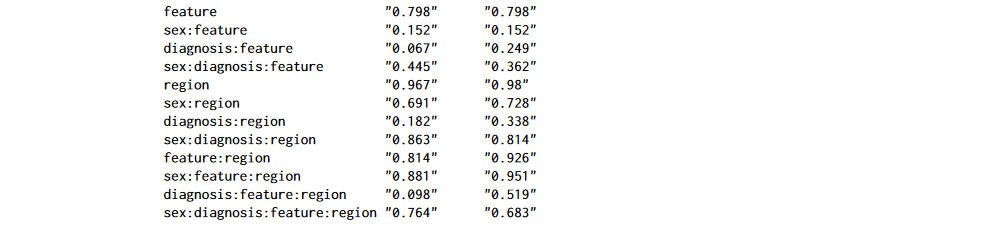

### Reproduced

**Copy from attached file**

```r
# Example 2
data("EEG")
EEG_model <- RM(resp ~ sex * diagnosis * feature * region,
                data = EEG, subject = "id", no.subf = 2, resampling = "WildBS",
                iter = 1000,  alpha = 0.01, CPU = 4, seed = 123)
summary(EEG_model)
```

```
## Call:
## resp ~ sex * diagnosis * feature * region
## A repeated measures analysis with  2 within-subject and  2 between-subject factors.
##
## Descriptive:
##    sex diagnosis    feature   region  n  Means Lower 99 % CI Upper 99 % CI
## 1    M        AD  brainrate  central 12 -1.010        -4.881         2.861
## 13   M        AD  brainrate  frontal 12 -1.007        -4.991         2.977
## 25   M        AD  brainrate temporal 12 -0.987        -4.493         2.519
## 7    M        AD complexity  central 12 -1.488       -10.053         7.077
## 19   M        AD complexity  frontal 12 -1.086        -6.906         4.735
## 31   M        AD complexity temporal 12 -1.320        -7.203         4.562
## 3    M       MCI  brainrate  central 27 -0.447        -1.591         0.696
## 15   M       MCI  brainrate  frontal 27 -0.464        -1.646         0.719
## 27   M       MCI  brainrate temporal 27 -0.506        -1.584         0.572
## 9    M       MCI complexity  central 27 -0.257        -1.139         0.625
## 21   M       MCI complexity  frontal 27 -0.459        -1.997         1.079
## 33   M       MCI complexity temporal 27 -0.490        -1.796         0.816
## 5    M       SCC  brainrate  central 20  0.459        -0.414         1.332
## 17   M       SCC  brainrate  frontal 20  0.243        -0.670         1.156
## 29   M       SCC  brainrate temporal 20  0.409        -1.210         2.028
## 11   M       SCC complexity  central 20  0.349        -0.070         0.767
## 23   M       SCC complexity  frontal 20  0.095        -1.037         1.227
## 35   M       SCC complexity temporal 20  0.314        -0.598         1.226
## 2    W        AD  brainrate  central 24 -0.294        -1.978         1.391
## 14   W        AD  brainrate  frontal 24 -0.159        -1.813         1.495
## 26   W        AD  brainrate temporal 24 -0.285        -1.776         1.206
## 8    W        AD complexity  central 24 -0.128        -1.372         1.116
## 20   W        AD complexity  frontal 24  0.026        -1.212         1.264
## 32   W        AD complexity temporal 24 -0.194        -1.670         1.283
## 4    W       MCI  brainrate  central 30 -0.106        -1.076         0.863
## 16   W       MCI  brainrate  frontal 30 -0.074        -1.032         0.885
## 28   W       MCI  brainrate temporal 30 -0.069        -1.064         0.925
## 10   W       MCI complexity  central 30  0.094        -0.464         0.652
## 22   W       MCI complexity  frontal 30  0.131        -0.768         1.031
## 34   W       MCI complexity temporal 30  0.121        -0.652         0.895
## 6    W       SCC  brainrate  central 47  0.537        -0.049         1.124
## 18   W       SCC  brainrate  frontal 47  0.548        -0.062         1.159
## 30   W       SCC  brainrate temporal 47  0.559        -0.015         1.133
## 12   W       SCC complexity  central 47  0.384         0.110         0.659
```

[output cut: 41 more lines]

```
## sex                          "<0.001"     "<0.001"
## diagnosis                    "<0.001"     "<0.001"
## sex:diagnosis                "0.119"      "0.124"
## feature                      "0.798"      "0.798"
## sex:feature                  "0.152"      "0.152"
## diagnosis:feature            "0.067"      "0.249"
## sex:diagnosis:feature        "0.445"      "0.362"
## region                       "0.967"      "0.98"
## sex:region                   "0.691"      "0.728"
## diagnosis:region             "0.182"      "0.338"
## sex:diagnosis:region         "0.863"      "0.814"
## feature:region               "0.814"      "0.926"
## sex:feature:region           "0.881"      "0.951"
## diagnosis:feature:region     "0.098"      "0.519"
## sex:diagnosis:feature:region "0.764"      "0.683"
```

## Plotting

### Plot 1 - Original

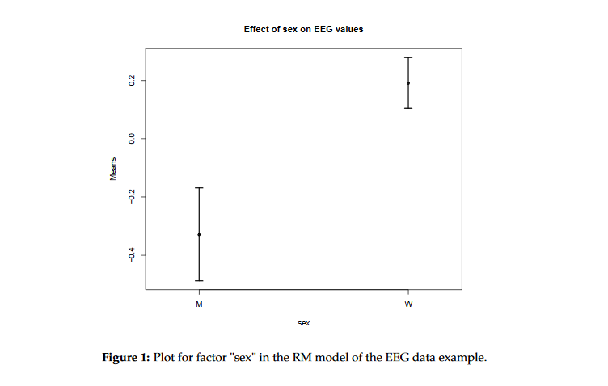

### Plot 1 - Reproduced

**Copy from attached file**

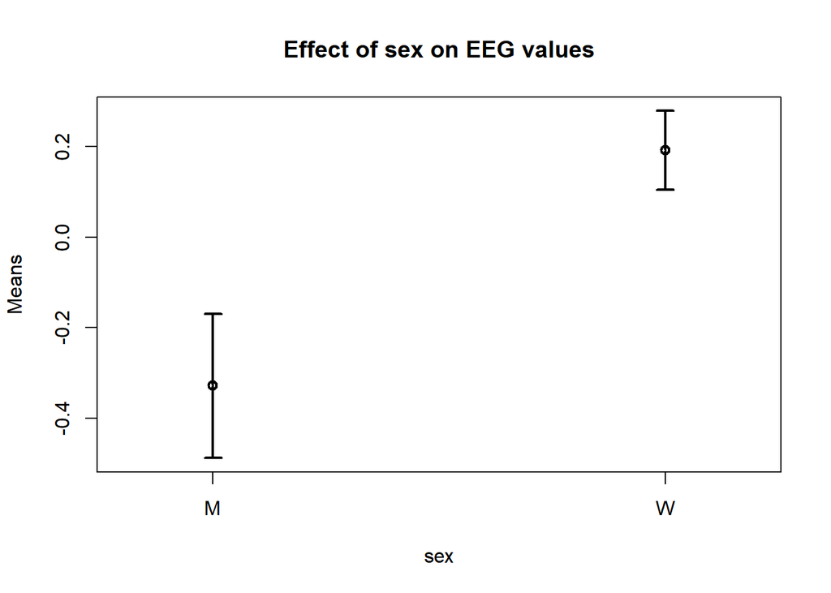

```r
plot(EEG_model, factor = "sex", main = "Effect of sex on EEG values")
```

### Plot 2 - Original

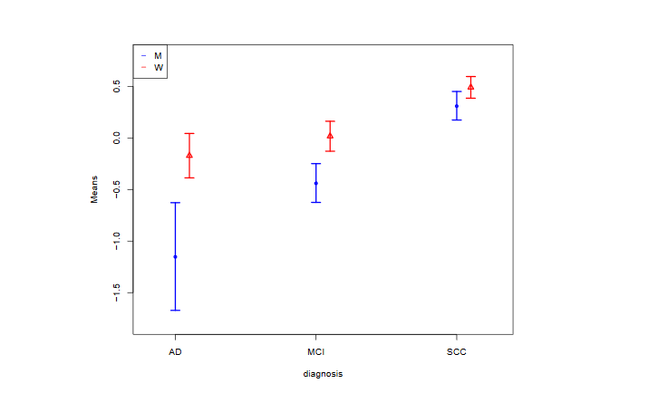

### Plot 2 - Reproduced

**Copy from attached file**

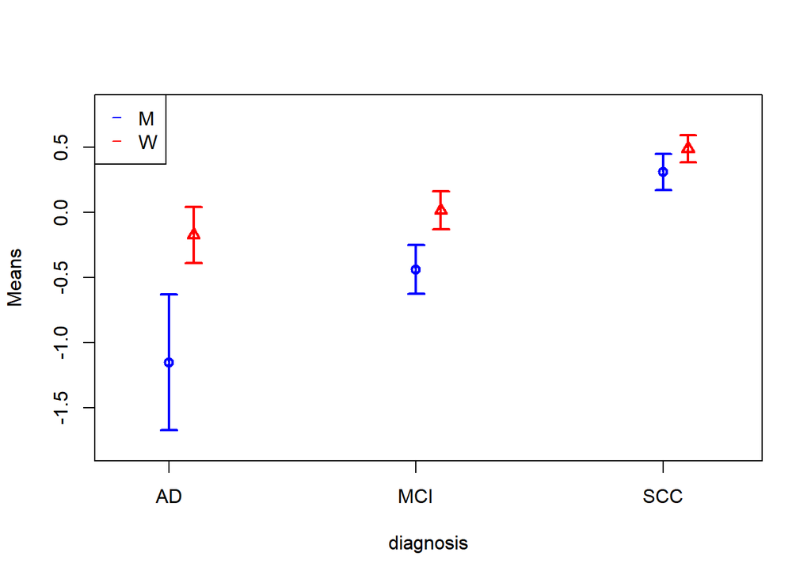

```
## $mean
##           AD         MCI       SCC
## M -1.1496245 -0.43724352 0.3114978
## W -0.1723434  0.01624054 0.4897902
##
## $lower
##           AD        MCI       SCC
## M -1.6714757 -0.6251940 0.1732354
## W -0.3874841 -0.1290226 0.3848516
##
## $upper
##            AD        MCI       SCC
## M -0.62777339 -0.2492930 0.4497601
## W  0.04279732  0.1615037 0.5947288
```

```r
plot(EEG_model, factor = "sex:diagnosis", legendpos = "topleft", col = c(4, 2), ylim =c(-1.8, 0.8), CI.info = TRUE)
```

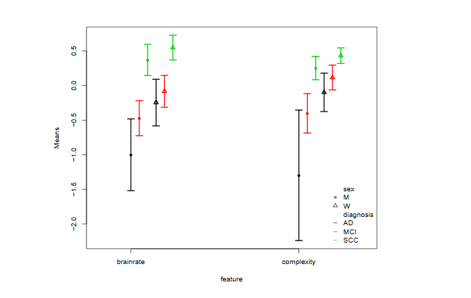

**Copy from attached file**

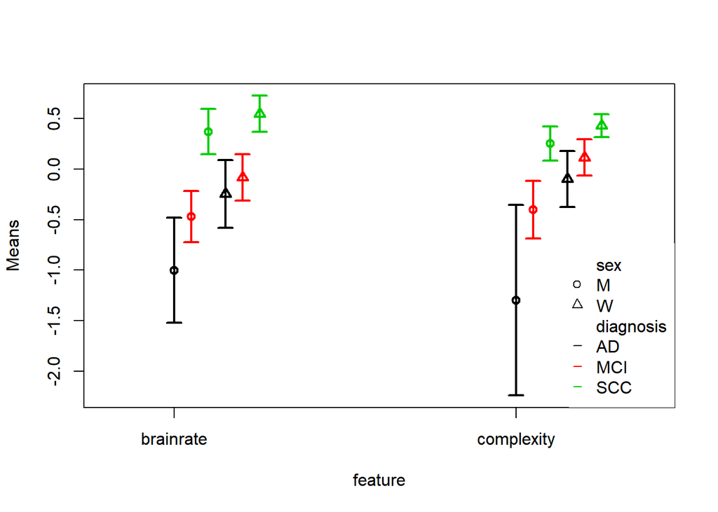

```r
plot(EEG_model, factor = "sex:diagnosis:feature", legendpos = "bottomright", gap = 0.05)
```

## MANOVA

### Original

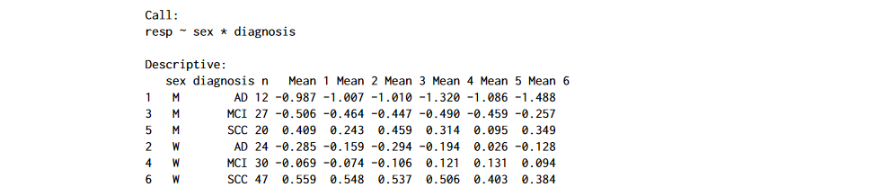

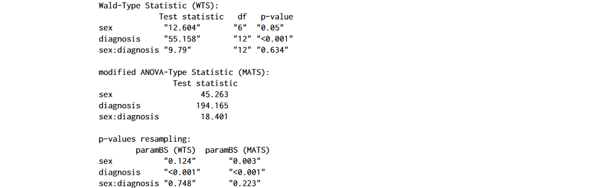

### Reproduced

**Copy from attached file**

```r
data("EEG")
EEG_MANOVA <- MANOVA(resp ~ sex * diagnosis, data = EEG,
                   subject = "id", resampling = "paramBS",
                   iter = 1000,  alpha = 0.01, CPU = 1, seed = 987)
summary(EEG_MANOVA)
```

```
## Call:
## resp ~ sex * diagnosis
##
## Descriptive:
##   sex diagnosis  n Mean 1 Mean 2 Mean 3 Mean 4 Mean 5 Mean 6
## 1   M        AD 12 -0.987 -1.007 -1.010 -1.320 -1.086 -1.488
## 3   M       MCI 27 -0.506 -0.464 -0.447 -0.490 -0.459 -0.257
## 5   M       SCC 20  0.409  0.243  0.459  0.314  0.095  0.349
## 2   W        AD 24 -0.285 -0.159 -0.294 -0.194  0.026 -0.128
## 4   W       MCI 30 -0.069 -0.074 -0.106  0.121  0.131  0.094
## 6   W       SCC 47  0.559  0.548  0.537  0.506  0.403  0.384
##
## Wald-Type Statistic (WTS):
##               Test statistic df   p-value
## sex           "12.604"       "6"  "0.05"
## diagnosis     "55.158"       "12" "<0.001"
## sex:diagnosis "9.79"         "12" "0.634"
##
## modified ANOVA-Type Statistic (MATS):
##               Test statistic
## sex                   45.263
## diagnosis            194.165
## sex:diagnosis         18.401
##
## p-values resampling:
##               paramBS (WTS) paramBS (MATS)
## sex           "0.124"       "0.003"
## diagnosis     "<0.001"      "<0.001"
## sex:diagnosis "0.748"       "0.223"
```